# Warmup 03

# Explore Living Area

```r
Living.Area = house$Living.Area
summary(house$Living.Area)
```

```
##    Min. 1st Qu.  Median    Mean 3rd Qu.    Max.
##     616    1302    1636    1757    2142    5228
```

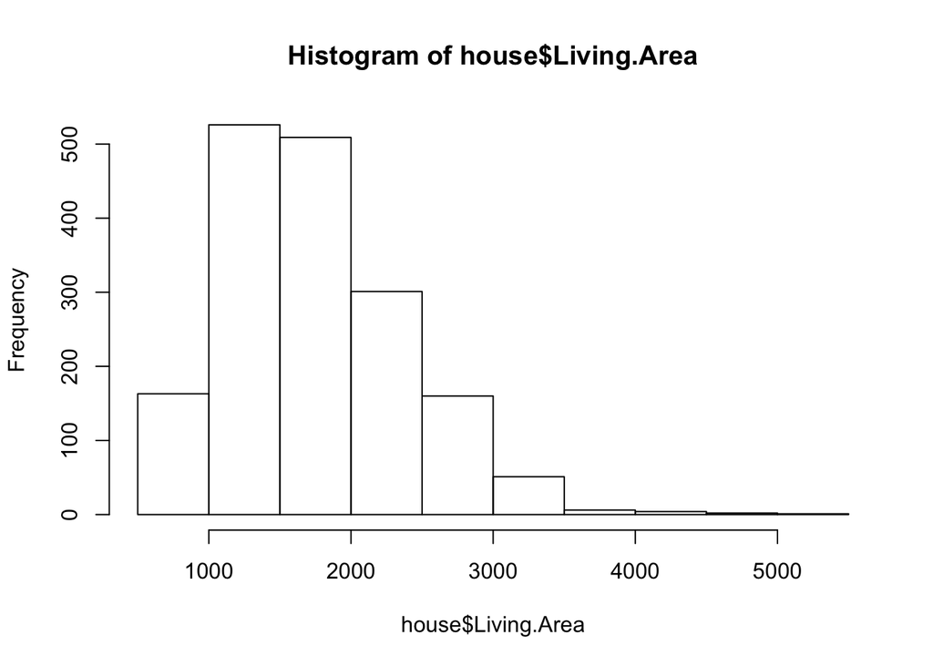

```r
hist(house$Living.Area)
```

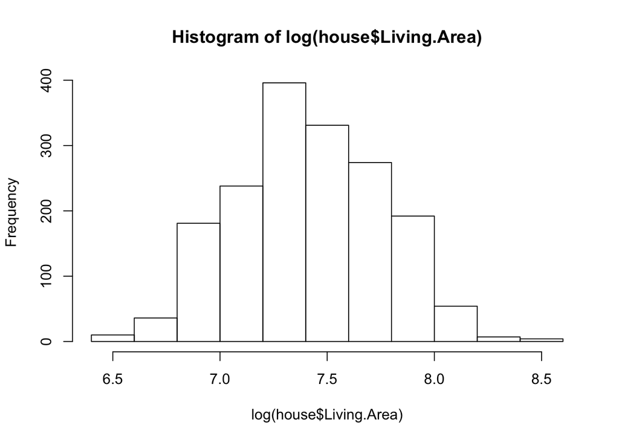

```r
hist(log(house$Living.Area)) #the large number values at 6.8 corresponds to around 885 in original units of measurement.
```

# Transforming Variables Into Factors

```r
BR = house$Bedrooms
BR[BR > 5] = 5
BR[BR < 2] = 2
BR = factor(BR, levels = c(2, 3, 4, 5), labels = c("2- BR", "3 BR", "4 BR", "5+ BR"))
summary(house$Bedrooms) #summary of bedroom
```

```
##    Min. 1st Qu.  Median    Mean 3rd Qu.    Max.
##   1.000   3.000   3.000   3.157   4.000   7.000
```

```r
summary(BR)
```

```
## 2- BR  3 BR  4 BR 5+ BR
##   351   821   487    64
```

The summary of BR looks different in the sense that it now combined some of the levels to make it easier to read. Instead of 7 levels, it has 4 levels with the 1/2 and 5/6/7 levels combined (and added) together. Instead of the integer as the labels as the number of rooms, it now has the strings with the associated numbers.